# 記述統計

#### 度数分布表

- 度数分布表とは?
  - data を **階級** に分けて階級ごとの **度数** を数えた表

#### histogram

- 度数分布表から縦軸に **度数** 横軸に **階級** をとり **グラフ化** したもの
  - 集団の特徴を定義付けていく

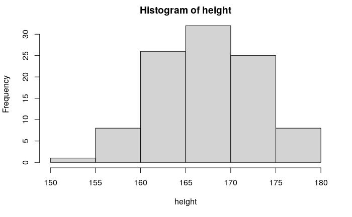

```r
height =
  rnorm(100, 167, 5)
y = hist(height)
```

```r
y
```

```
$breaks
[1] 150 155 160 165 170 175 180

$counts
[1]  1  8 26 32 25  8

$density
[1] 0.002 0.016 0.052 0.064 0.050 0.016

$mids
[1] 152.5 157.5 162.5 167.5 172.5 177.5

$xname
[1] "height"

$equidist
[1] TRUE

attr(,"class")
[1] "histogram"
```

### 基本統計量

分布の基本的な特性を数値で表した指標

- **代表値** (分布の中心を表す指標)
  - *平均* : (算術平均, 幾何平均, 調和平均, 加重平均)
  - *中央値(メジアン)*
  - *最頻値(モード)*
- **散布度** (分布のばらつきを表す指標)
  - *範囲(レンジ)*
  - *四分位範囲*
  - *平均偏差*
  - **分散**
  - **標準偏差**
  - *変動係数*
  - *標準化得点*

### 算術平均

中心を表す指標

- 全ての data を足して個数で割った値 = **平均** = $\mu$
  - **長所**
    - 一般的, 計算が簡単, 数値の意味の理解のし易さ
  - **短所**
    - 外れ値の影響を受けやすい, 分布の形状に依存する

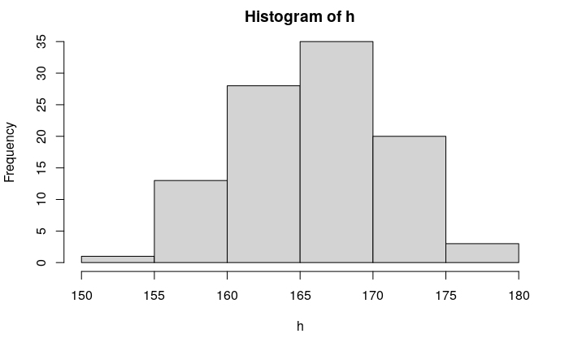

```r
h = as.integer(height)
hist(h)
```

```r
mean(h)
```

```
[1] 166.62
```

```r
median(h)
```

```
[1] 167
```

- **平均** : 166.62 cm | **中央値** : 167 cm
  - 解析する histograme の形を考慮して `mean( )`, `median( )` を使い分けていく
- **summary( )** : 一度に様々な数値を取得できる
  - Min : 最小 | 1st : 25% | Median : 中央値 | Mean : 平均 | 3rd : 75% | Max : 最大値

```r
summary(h)
```

```
   Min. 1st Qu.  Median    Mean 3rd Qu.    Max.
  152.0   163.0   167.0   166.6   170.0   178.0
```

### 分散・標準偏差

ばらつきを表す指標

- 平均との差の二乗平均を求めた値 **分散**($\sigma^2$) その平方根 **標準偏差**($\sigma$)
  - **長所**
    - バラつきの数値で最も一般的, 理論的に扱いやすい
  - **短所**
    - 分散は単位が分かりづらい

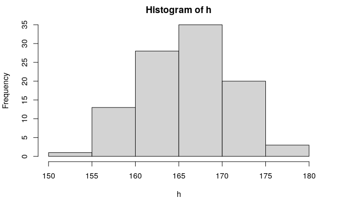

```r
hist(h)
```

```r
var(h)
```

```
[1] 29.06626
```

```r
sd(h)
```

```
[1] 5.391314
```

- **分散** : 29.0662626 | **標準偏差** : 5.3913136
  - ※ R言語の分散は **不偏分散** なので注意!

### 標準化

data の **平均値を 0 , 分散を 1** に変換する操作

$$\frac{X - \mu}{\sigma}$$

（それぞれの値 - 平均） ÷ 標準偏差 = 標準化  
↓

#### 標準化により異なる集団も全て **標準得点** で比較できる

||  
scale を合わせて比較することが出来る

```r
x
```

[output not shown]

```r
head(scale(h))
```

```
           [,1]
[1,] -1.2279011
[2,] -0.3004834
[3,] -0.3004834
[4,] -0.4859669
[5,] -1.5988682
[6,] -0.1149998
```

```r
var(scale(h))
```

```
     [,1]
[1,]    1
```

```r
mean(scale(h))
```

```
[1] -8.365444e-16
```

- **標準化** : scale( )
  - 標準化後の **分散** : 1
  - 標準化後の **平均** : -8.3654438^{-16}

### 正規分布

左右対称つり鐘型をした **確率分布** 多くの現象がこの分布に従う  
→ 身長, 植物の大きさ, testの点数, 工業製品の誤差 etc…

- **確率分布**
  - グラフの **面積が確率** なるようなグラフ
    - 全部足すと **1** になる = **確率 100%**
    - `平均値` と `標準偏差` で形が決まる
    - *数学的に一意に決まるグラフ*

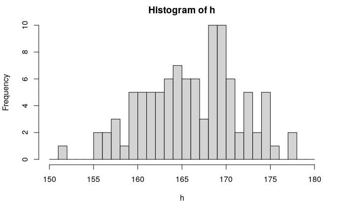

```r
hist(h, breaks = seq(150, 180, 1))
```

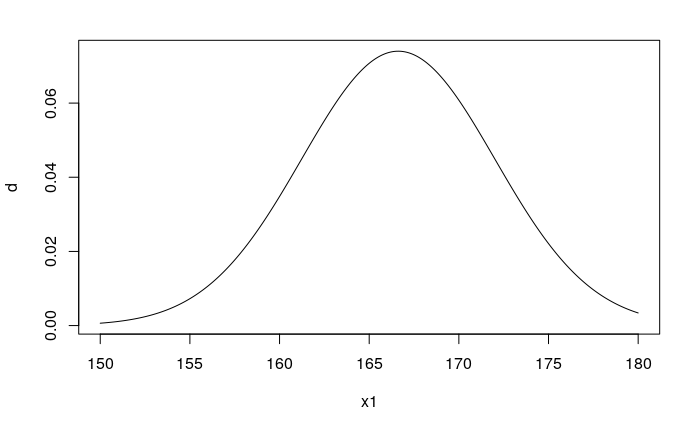

```r
m <- mean(h)
s <- sd(h)
x1 <- seq(150, 180, 0.01)
d = dnorm(x1, mean = m, sd = s)
plot(x1, d, type = "l")
```

- **平均** : 166.62 cm | **標準偏差** : 5.3913136

### 正規分布から分かること

分布のある範囲に **どれだけのdataが含まれているか** が分かる

面積が分かるという事は  
||

##### その範囲に入る **dataの確率** が分かる

```r
sc <- 850
m1 <- 582.6
s1 <- 172.7
n <- as.integer(103955)
Z = (X1 - m1)/s1
```

**自分の得点** : $X$ = 850 | **平均点** $\mu$ : 582.6 | **標準偏差** $\sigma$ : 172.7 | **標準化** : 1.5483497 | **総数(人)** : 103955

#### 標準化

$$Z = \frac{得点 - 平均値}{標準偏差}$$

#### 公式

$$Z = \frac{X - \mu}{\sigma} = \frac{850 - 582.6}{172.7} \simeq 1.55$$

#### 正規分布の面積を求める

- Rの場合 pnorm( )では, **無限大の -** (マイナス)方向から **1.55** までを求める
  - なので **- 0.5** で 0 から ー 方向の面積を引く

```r
d = pnorm(Z, mean = 0, sd = 1)
d
```

```
[1] 0.9392309
```

```r
d2 = pnorm(Z, mean = 0, sd = 1) - 0.5
d2
```

```
[1] 0.4392309
```

```r
N = 1 - d
N
```

```
[1] 0.06076906
```

```r
N1 = as.integer(n*(1 - d)*100)
N1
```

```
[1] 631724
```